# Indel Signature InsDel_B

# InsDel_B

(corresponds to 83-type signature ID_B)

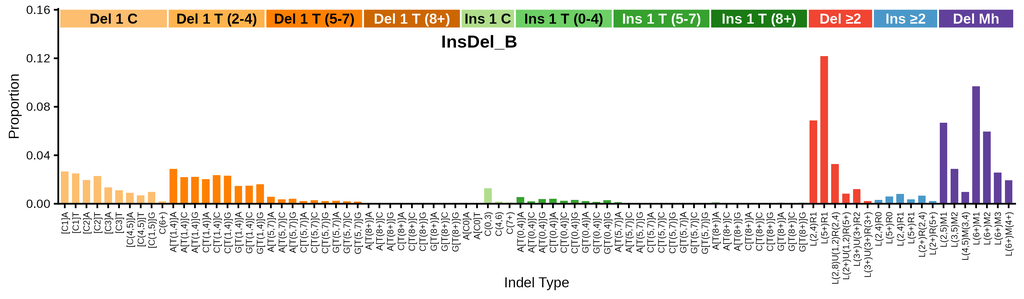

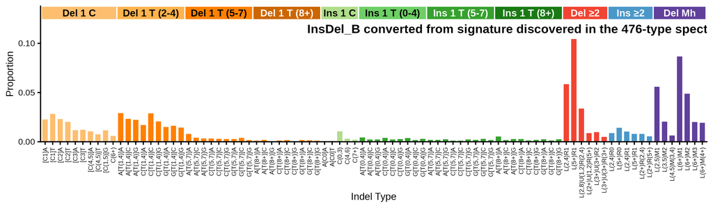

89-type spectrum of the linking tumor CPCT02020413T | cosine similarity to InsDel_B: 0.9872

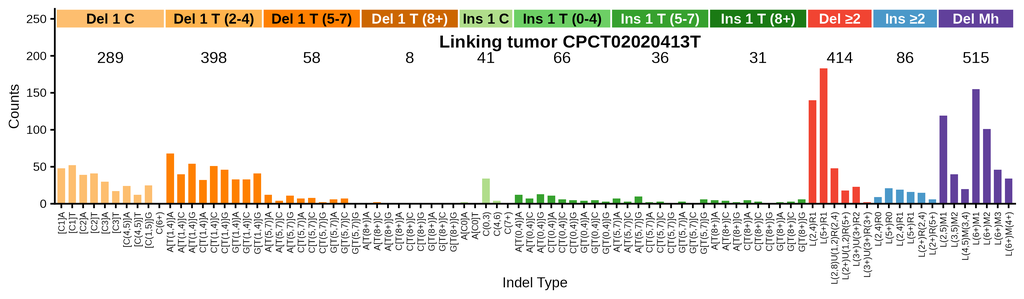

**Click to view decomposition of the linking tumor spectrum**

Partial mutation signature of CPCT02020413T due to InsDel_B

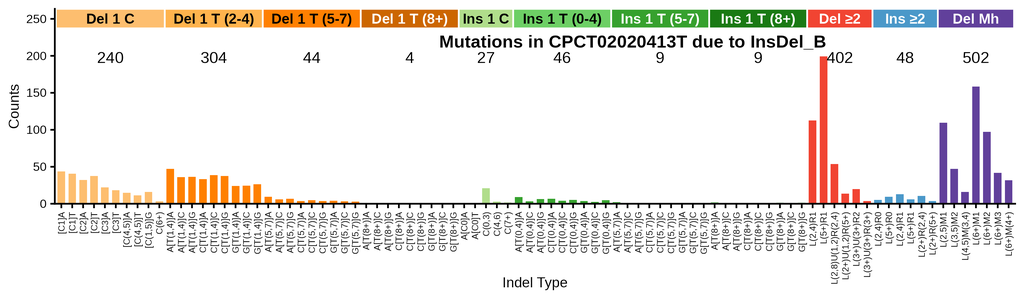

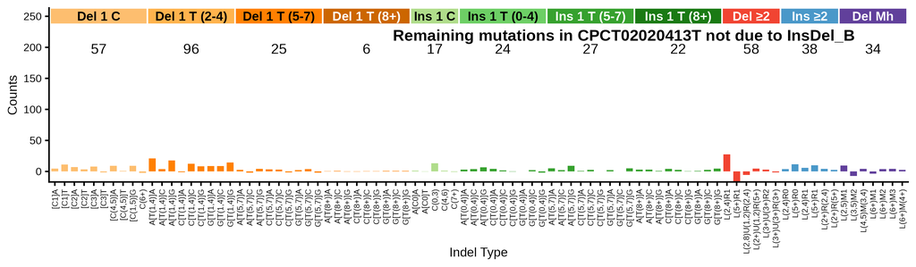

Max neg fraction (maximum allowed negative residual count as fraction of total): 0.03  
N subtract (mutation count assigned to signature): 1634.8  
N residual (mutation count in residual “partial spectrum”): 307.2  
Total negative (sum of negative residual mutation counts): 48.5  
N negative channels (number of channels with negative residual): 18  
P(≥ total negative) (Monte Carlo estimated probability that negative-binomial-sampled spectra from the signature contributing N subtract mutations would produce a total negative count >= the observed Total negative; higher number means not surprising): 0.996

**Per-channel residual breakdown**

| Channel | Spectrum | Sig_Count | Residual | Sig_Prop |
| --- | --- | --- | --- | --- |
| [Del(C):R1]A | 48 | 43.6 | 4.4 | 0.02666 |
| [Del(C):R1]T | 52 | 40.7 | 11.3 | 0.02491 |
| [Del(C):R2]A | 39 | 32.0 | 7 | 0.01956 |
| [Del(C):R2]T | 41 | 37.5 | 3.5 | 0.02297 |
| [Del(C):R3]A | 30 | 22.0 | 8 | 0.01346 |
| [Del(C):R3]T | 17 | 18.4 | -1.4 | 0.01123 |
| [Del(C):R(4,5)]A | 24 | 14.7 | 9.3 | 0.00899 |
| [Del(C):R(4,5)]T | 12 | 11.2 | 0.8 | 0.00687 |
| [Del(C):R(1,5)]G | 25 | 16.0 | 9 | 0.00981 |
| Del(C):R(6,9) | 1 | 3.4 | -2.4 | 0.00206 |
| A[Del(T):R(1,4)]A | 68 | 47.2 | 20.8 | 0.02886 |
| A[Del(T):R(1,4)]C | 40 | 36.1 | 3.9 | 0.02208 |
| A[Del(T):R(1,4)]G | 54 | 36.4 | 17.6 | 0.02227 |
| C[Del(T):R(1,4)]A | 32 | 33.1 | -1.1 | 0.02027 |
| C[Del(T):R(1,4)]C | 51 | 38.5 | 12.5 | 0.02358 |
| C[Del(T):R(1,4)]G | 46 | 37.7 | 8.3 | 0.02308 |
| G[Del(T):R(1,4)]A | 33 | 24.1 | 8.9 | 0.01473 |
| G[Del(T):R(1,4)]C | 33 | 24.4 | 8.6 | 0.01493 |
| G[Del(T):R(1,4)]G | 41 | 26.5 | 14.5 | 0.01619 |
| A[Del(T):R(5,7)]A | 12 | 9.3 | 2.7 | 0.00570 |
| A[Del(T):R(5,7)]C | 4 | 6.0 | -2 | 0.00370 |
| A[Del(T):R(5,7)]G | 11 | 6.7 | 4.3 | 0.00413 |
| C[Del(T):R(5,7)]A | 7 | 3.7 | 3.3 | 0.00226 |
| C[Del(T):R(5,7)]C | 8 | 4.8 | 3.2 | 0.00297 |
| C[Del(T):R(5,7)]G | 2 | 3.5 | -1.5 | 0.00213 |
| G[Del(T):R(5,7)]A | 6 | 4.0 | 2 | 0.00246 |
| G[Del(T):R(5,7)]C | 7 | 3.2 | 3.8 | 0.00194 |
| G[Del(T):R(5,7)]G | 1 | 3.0 | -2 | 0.00186 |
| A[Del(T):R(8,)]A | 1 | 0.6 | 0.4 | 0.00034 |
| A[Del(T):R(8,)]C | 2 | 1.0 | 1 | 0.00061 |

[output cut: 59 more lines]

## 476-type representations corresponding to InsDel_B

Extracted 476-type signature corresponding to InsDel_B

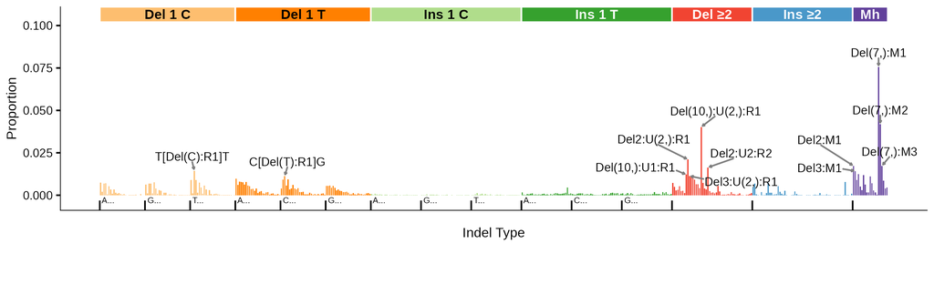

476-type spectrum of the linking tumor CPCT02020413T; cosine similarity to the extracted 476-type signature is 0.9719

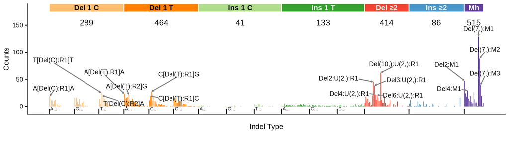

## 83-type signature corresponding to InsDel_B (ID_B)

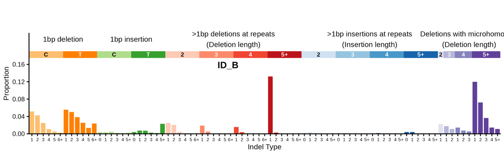

83-type signature converted from signature discovered in the 476-type spectra (using bipartite matching optimization) | cosine similarity to ID_B: 0.9817

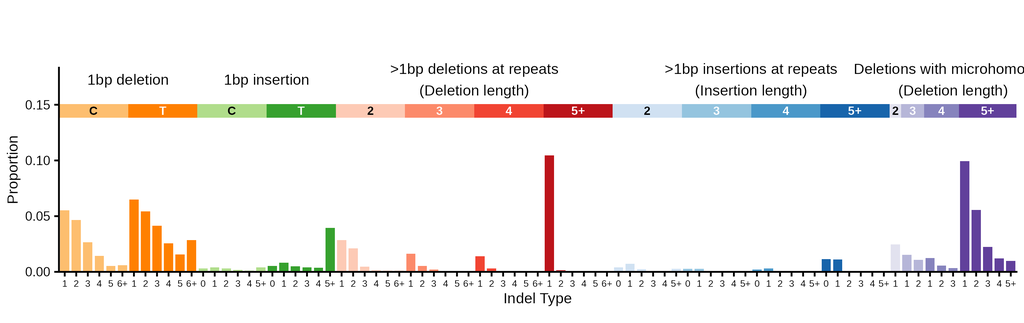

**Click to see flow diagrams: 476-type to 83-type collapse**

These Sankey diagrams show how the 476-type mutation categories are redistributed to 83-type categories using bipartite matching. We only show the diagrams for insertions or deletions of > 1 base because it is for these indels that 476-type categories map to > 1 83-type category.

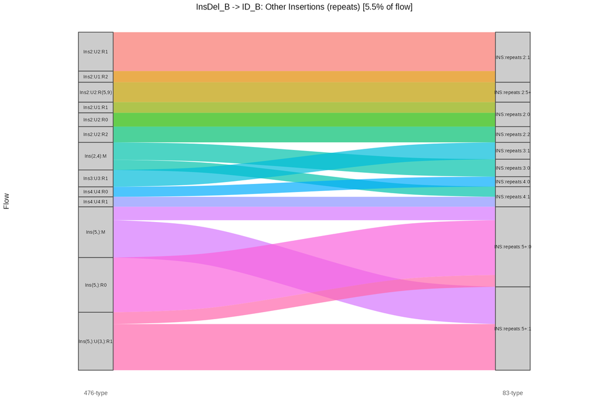

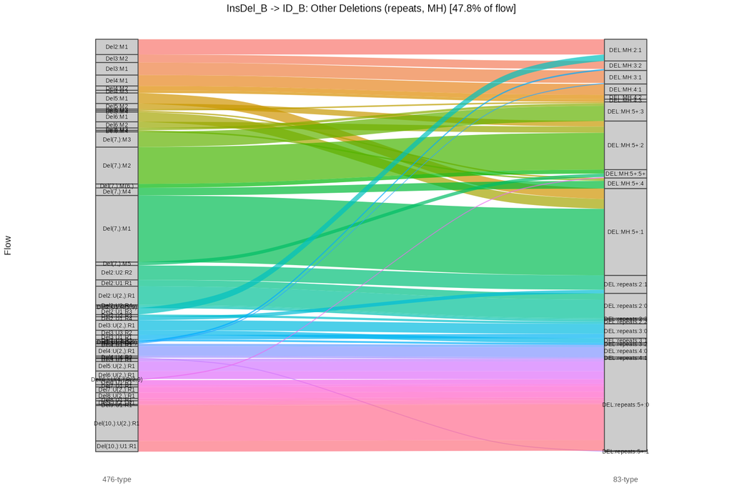

83-type spectrum of the linking tumor CPCT02020413T | cosine similarity to ID_B: 0.9659

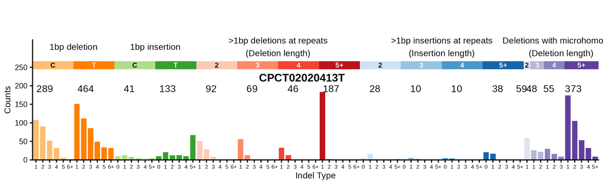

83-type spectrum of best 83-type matching tumor SP116578 | cosine similarity to ID_B: 0.983

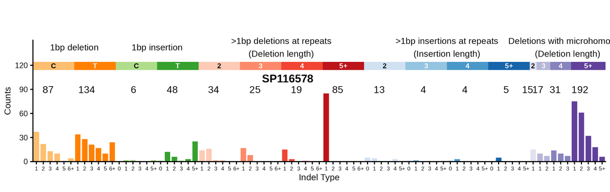